# Reproducible Research Project 1

This is Coursera Reproducible Research Project Week 2 Peer Review Assignement.

```r
library(pander)

library(tidyverse)

library(xtable)

library(knitr)

library(gridExtra)

options(xtable.comment = FALSE)
```

```r
inline_hook <- function (x) {
  if (is.numeric(x)) {
    ## ifelse does a vectorized comparison
    ## If integer, print without decimal; otherwise print two places
    res <- ifelse(x == round(x),
      sprintf("%d", x),
      sprintf("%.2f", x)
    )
    paste(res, collapse = ", ")
  }
}

knit_hooks$set(inline = inline_hook)
```

# 1 Loading and Preprocessing Data

1. load the data
2. Process/transform the data

```r
activity <- read.csv("activity.csv")

pander(head (activity, 6))
```

| steps | date | interval |
| --- | --- | --- |
| NA | 2012-10-01 | 0 |
| NA | 2012-10-01 | 5 |
| NA | 2012-10-01 | 10 |
| NA | 2012-10-01 | 15 |
| NA | 2012-10-01 | 20 |
| NA | 2012-10-01 | 25 |

```r
table(is.na(activity$steps))
```

```
##
## FALSE  TRUE
## 15264  2304
```

```r
table(is.na(activity$date))
```

```
##
## FALSE
## 17568
```

```r
table(is.na(activity$interval))
```

```
##
## FALSE
## 17568
```

3. remove the missing value

```r
activity_NARemoved <- na.omit(activity)
```

# 2 Mean Total Number of Steps Taken per Day

1. calculate the total number of steps per day

```r
DailyStep <- activity_NARemoved %>% group_by(date) %>%
    summarise(Daily_Step = sum(steps))

sum(is.na(DailyStep))
```

```
## [1] 0
```

```r
pander(head(DailyStep,6))
```

| date | Daily_Step |
| --- | --- |
| 2012-10-02 | 126 |
| 2012-10-03 | 11352 |
| 2012-10-04 | 12116 |
| 2012-10-05 | 13294 |
| 2012-10-06 | 15420 |
| 2012-10-07 | 11015 |

```r
DailyStep$Daily_Step <- as.numeric(DailyStep$Daily_Step)
```

2. Histogram: the total number of steps taken each day

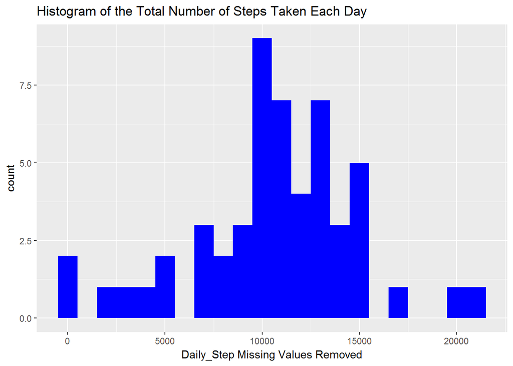

```r
DailyStepHist <- ggplot (DailyStep, aes(Daily_Step)) +
    geom_histogram(fill ="blue",binwidth = 1000)+
    labs(title = "Histogram of the Total Number of Steps Taken Each Day", x = "Daily_Step Missing Values Removed")

DailyStepHist
```

3. Mean and Median of the total number of steps taken per day

The mean of the total number of steps taken per day with missing value is `10766.19`, and

the median of the total number of streps taken per day with missing value is `10765`.

```r
mean(DailyStep$Daily_Step)
```

```
## [1] 10766.19
```

```r
median(DailyStep$Daily_Step)
```

```
## [1] 10765
```

# 3 The Average Daily Activity Pattern

1. A time series plot of the 5-minute interval (x-axis) and the average number of steps taken, averaged across all days (y-axis)

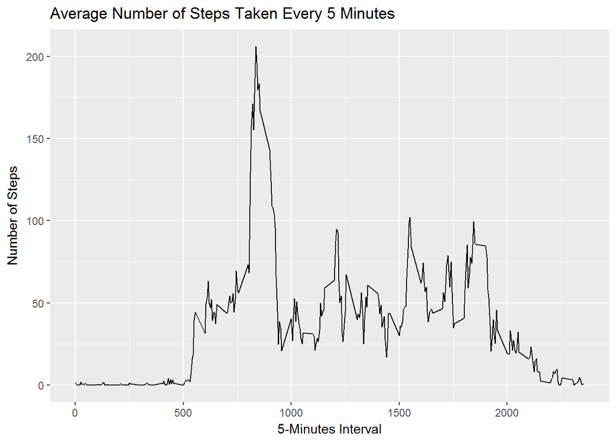

```r
five_min_steps <- activity_NARemoved %>% group_by(interval) %>%
    summarise(StepsPerFiveMin = mean(steps))

five_min_steps_TimeSeries <- ggplot(five_min_steps,aes(interval,StepsPerFiveMin))+
    geom_line()+ylab("Number of Steps")+xlab("5-Minutes Interval")+
    ggtitle("Average Number of Steps Taken Every 5 Minutes")

five_min_steps_TimeSeries
```

2. Which 5-minute interval, on average across all the days in the dataset, contains the maximum number of steps?

The maximum number of steps

```r
Max_Steps <- five_min_steps[five_min_steps$StepsPerFiveMin == max(five_min_steps$StepsPerFiveMin),]

pander(Max_Steps)
```

| interval | StepsPerFiveMin |
| --- | --- |
| 835 | 206.2 |

# 4 Imputing missing values

1. the total number of missing values in the dataset is `2304`

```r
sum(is.na(activity$steps))
```

```
## [1] 2304
```

2. Assign mean to the missing values

Calculate mean within `activity_NARemoved` data frame.

```r
AverageByInterval <- activity_NARemoved %>% group_by(interval) %>%
    summarise(AverageSteps = mean(steps))

pander(head(AverageByInterval,6))
```

| interval | AverageSteps |
| --- | --- |
| 0 | 1.717 |
| 5 | 0.3396 |
| 10 | 0.1321 |
| 15 | 0.1509 |
| 20 | 0.07547 |
| 25 | 2.094 |

Prepare a data frame for missing value only

```r
activityMissingValue <- activity %>% filter(is.na(steps)) %>% group_by(interval,date)

pander(head(activityMissingValue))
```

| steps | date | interval |
| --- | --- | --- |
| NA | 2012-10-01 | 0 |
| NA | 2012-10-01 | 5 |
| NA | 2012-10-01 | 10 |
| NA | 2012-10-01 | 15 |
| NA | 2012-10-01 | 20 |
| NA | 2012-10-01 | 25 |

Assign mean values to the missing value using `merge function`

```r
AssignMissingValue <- merge(activityMissingValue, AverageByInterval, by="interval")

pander(head(AssignMissingValue,3))
```

| interval | steps | date | AverageSteps |
| --- | --- | --- | --- |
| 0 | NA | 2012-10-01 | 1.717 |
| 0 | NA | 2012-11-30 | 1.717 |
| 0 | NA | 2012-11-04 | 1.717 |

```r
AssignMissingValue <- AssignMissingValue [, c(1,3,4)]

pander(head(AssignMissingValue,3))
```

| interval | date | AverageSteps |
| --- | --- | --- |
| 0 | 2012-10-01 | 1.717 |
| 0 | 2012-11-30 | 1.717 |
| 0 | 2012-11-04 | 1.717 |

All missing values have been imputed using the mean value.

```r
## rename data frame

colnames(AssignMissingValue) = c("interval","date","steps")

pander(head(AssignMissingValue,3))
```

| interval | date | steps |
| --- | --- | --- |
| 0 | 2012-10-01 | 1.717 |
| 0 | 2012-11-30 | 1.717 |
| 0 | 2012-11-04 | 1.717 |

Combine two dataframes

```r
activity2 <- rbind(activity_NARemoved,AssignMissingValue)

pander(head(activity2,6))
```

|  | steps | date | interval |
| --- | --- | --- | --- |
| **289** | 0 | 2012-10-02 | 0 |
| **290** | 0 | 2012-10-02 | 5 |
| **291** | 0 | 2012-10-02 | 10 |
| **292** | 0 | 2012-10-02 | 15 |
| **293** | 0 | 2012-10-02 | 20 |
| **294** | 0 | 2012-10-02 | 25 |

check total observation in the activity2 - missing value filled adn activity- original data set

```r
dim(activity)
```

```
## [1] 17568     3
```

```r
dim(activity2)
```

```
## [1] 17568     3
```

checking on number of NA

```r
sum(is.na(activity2$steps))
```

```
## [1] 0
```

calculate the total steps per day

```r
activityFull <- activity2 %>% group_by(date) %>% summarise(Daily_Step = sum(steps))

pander(head(activityFull,6))
```

| date | Daily_Step |
| --- | --- |
| 2012-10-01 | 10766 |
| 2012-10-02 | 126 |
| 2012-10-03 | 11352 |
| 2012-10-04 | 12116 |
| 2012-10-05 | 13294 |
| 2012-10-06 | 15420 |

Mean and Median in the new dataset activity2 - no missing value. The mean after missing value filled is `10766.19`, and the median afer missing values filled is `10766.19`

```r
mean(activityFull$Daily_Step)
```

```
## [1] 10766.19
```

```r
median (activityFull$Daily_Step)
```

```
## [1] 10766.19
```

Compare dataset with missing value filled to the dataset with missing value

```r
Item <- c("Mean","Median")
OriginalData <- c(mean(DailyStep$Daily_Step),median(DailyStep$Daily_Step))
ImputedData <- c(mean(activityFull$Daily_Step),median(activityFull$Daily_Step))
Compare <- data.frame(Item,OriginalData,ImputedData)

pander(Compare)
```

| Item | OriginalData | ImputedData |
| --- | --- | --- |
| Mean | 10766 | 10766 |
| Median | 10765 | 10766 |

make a Histogram on the new dataset

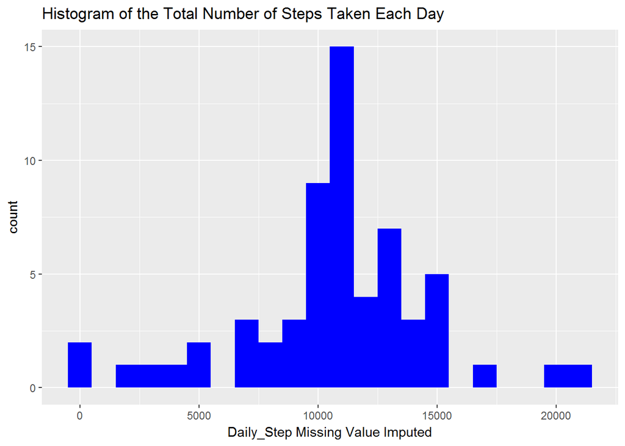

```r
DailyStepHistFull <- ggplot (activityFull, aes(x=Daily_Step)) +
    geom_histogram(fill ="blue",binwidth = 1000)+
    labs(title = "Histogram of the Total Number of Steps Taken Each Day", x = "Daily_Step Missing Value Imputed")

DailyStepHistFull
```

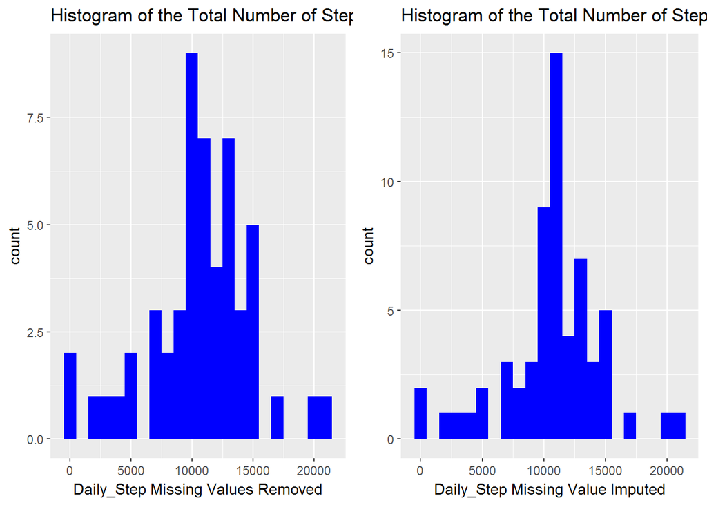

```r
grid.arrange(DailyStepHist,DailyStepHistFull,ncol=2)
```

# 5 Differences in activity patterns between weekdays and weekends

the dataset with missing values filled in is used for this.The dataset is `activity2`.

add new variable to the `activity2`dataset

```r
activity2$date <- as.Date(activity2$date)

activity2$DayType <- ifelse(
    weekdays(activity2$date, abbreviate = FALSE)
    %in% c("Monday", "Tuesday", "Wednesday", "Thursday", "Friday"),
"Weekdays","Weekend")

activity2$DayType <- as.factor(activity2$DayType)
```

check the levels

```r
levels(activity2$DayType)
```

```
## [1] "Weekdays" "Weekend"
```

Review the dataset

```r
pander(head(activity2,6))
```

|  | steps | date | interval | DayType |
| --- | --- | --- | --- | --- |
| **289** | 0 | 2012-10-02 | 0 | Weekdays |
| **290** | 0 | 2012-10-02 | 5 | Weekdays |
| **291** | 0 | 2012-10-02 | 10 | Weekdays |
| **292** | 0 | 2012-10-02 | 15 | Weekdays |
| **293** | 0 | 2012-10-02 | 20 | Weekdays |
| **294** | 0 | 2012-10-02 | 25 | Weekdays |

Prepare two new dataset

```r
Weekdays <- activity2 %>% filter (DayType == "Weekdays") %>%
    group_by(interval) %>% summarise(Average = mean(steps))

Weekend <- activity2 %>% filter (DayType == "Weekend") %>%
    group_by(interval) %>% summarise(Average = mean(steps))
```

Review the two new dataset

```r
pander(head(Weekdays,3))
```

| interval | Average |
| --- | --- |
| 0 | 2.251 |
| 5 | 0.4453 |
| 10 | 0.1732 |

```r
pander(head(Weekend,3))
```

| interval | Average |
| --- | --- |
| 0 | 0.2146 |
| 5 | 0.04245 |
| 10 | 0.01651 |

Create two timeserie

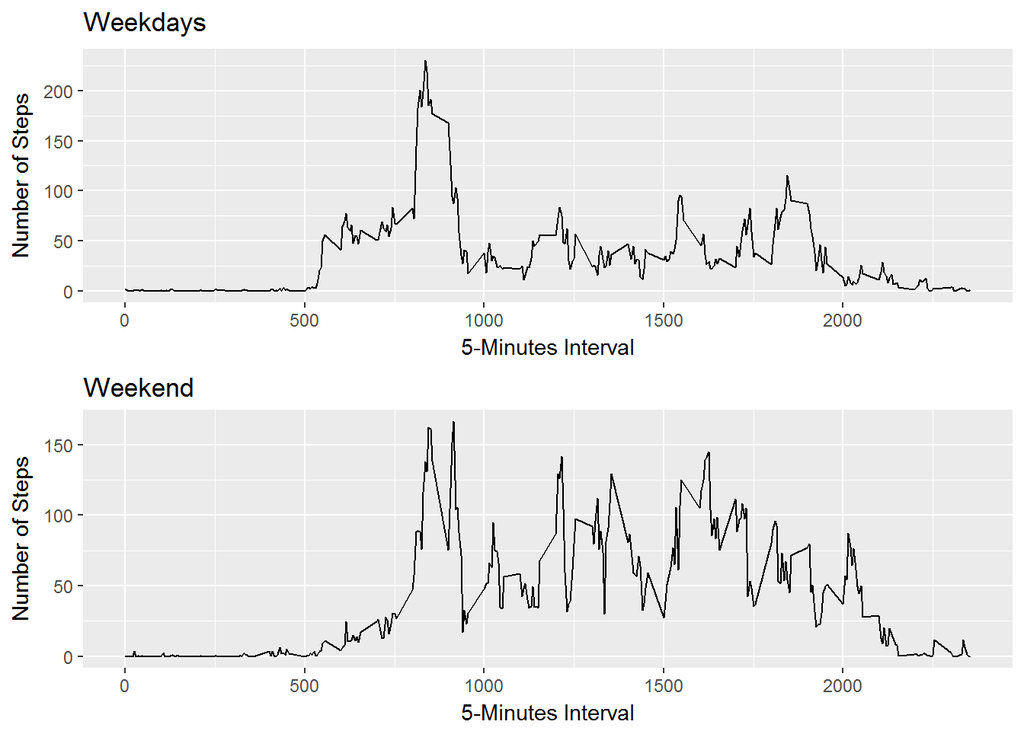

```r
WeekdaysTimeSerie <- ggplot(Weekdays,aes(interval,Average))+
    geom_line()+ylab("Number of Steps")+xlab("5-Minutes Interval")+
    ggtitle("Weekdays")

WeekendTimeSerie <- ggplot(Weekend,aes(interval,Average))+
    geom_line()+ylab("Number of Steps")+xlab("5-Minutes Interval")+
    ggtitle("Weekend")

grid.arrange(WeekdaysTimeSerie,WeekendTimeSerie,nrow = 2)
```